# NoSQL zadanie 2

Mateusz Miotk

08.11.2014

```
Sprzęt:
Laptop ACER ASPIRE ONE 5820TG
Procesor: Intel core I5-430M
Ilość pamięci RAM: 4 GB
Dysk twardy: SSD SanDisk 128 GB
System Operacyjny: Linux Mint 17 x64
Wersja MongoDB: 2.6.5 oraz 2.8.0.rc0
Wersja PostgreSQL: 9.3.5
```

## Zadanie 2: Aggregacje w MongoDB: Angielskie sentencje.

### Przygotowanie danych

Do wykonania zadania 2 wykorzystałem bazę danych ze strony **kaggle.com**, które zawiera około 3 milionów sentencji angielskich. Do eksperymentu wykorzystałem jedynie 1/3 tych danych. Jednak aby zapisać je w bazie MongoDB należy wstępnie przetworzyć te dane. Wykonuje to przy pomocy języka R.

#### Odnośnik do danych ze strony kaggle.com

```html
https://www.kaggle.com/c/billion-word-imputation
```

[Bilion-word-imputation](https://www.kaggle.com/c/billion-word-imputation)

#### Format danych

Przetworzone dane są w następującej postaci:

```javascript
{
  "_id": ObjectId("546a54bc4fd537d62c6731c6"),
  "originalText": "what a world cup",
  "numberSentence": 20,
  "text": [
    "what",
    "a",
    "world",
    "cup"
  ],
  "howWords": 4
}
```

Aby jednak sprowadzić te dane do takiej postaci należy uruchomić skrypt **Load.R**.

Skrypt **Load.R** robi następujące rzeczy:

1. Czyta plik wiersz po wierszu.
2. Zamienia duże litery na małe oraz usuwa wszystkie znaki interpunkcyjne oraz dokonuje split sentencji.
3. Sprowadza dane wiersze do formatu **BSON**.
4. I wrzuca dane w tej postaci do MongoDB do kolekcji o nazwie **marta**.

UWAGA!!!

1. Punkt **2** skryptu jest wykonywane **równolegle**.
2. Nie bierzemy pod uwagę sentencji jednowyrazowych.
3. Na raz przetwarzamy 25000 wierszy z pliku.
4. Wrzucanie danych robimy poleceniem **mongo.batch.insert()**.

| Przetwarzanie danych i wrzucenie danych |
| --- |
| 35 minut i 30 sekund MongoDB 2.6.5 |
| 21 minut i 18 sekund MongoDB 2.8.0.rc0 wiredtiger |

### Przykłady agregacji

Interesować nas będą następujące pytania:

1. Zliczenie wszystkich słów i wypisanie 5 najczęstszych.
2. Wypisanie ilości słów najdłuższej sentencji.
3. Wypisanie z ilu słów jest najwięcej sentencji.
4. Wypisanie z ile sentencji ma najmniejszą ilość słów.

#### Zliczenie wszystkich słów i wypisanie 5 najczęstszych.

##### Przypadek 1: javascript.

Wykonuje to skrypt **first.js**.

```javascript
var options = {allowDiskUse: true, cursor: {batchSize: 4}};
var project = {$project: {text: 1, _id: 0}};
var unwind = {$unwind: "$text"};
var group = {$group: {_id: "$text", ilosc: {$sum : 1}}};
var sort = {$sort: {ilosc: -1}};
var limit = {$limit: 5};

var cursor = db.marta.aggregate([
  project,
  unwind,
  group,
  sort,
  limit
  ], options);
...
```

Wyjście:

```javascript
{ "_id" : "the", "ilosc" : 1363202 }
Średnia wynosi:  1.363202
{ "_id" : "to", "ilosc" : 606073 }
Średnia wynosi:  0.606073
{ "_id" : "of", "ilosc" : 575939 }
Średnia wynosi:  0.575939
{ "_id" : "a", "ilosc" : 550661 }
Średnia wynosi:  0.550661
{ "_id" : "and", "ilosc" : 537527 }
Średnia wynosi:  0.537527
```

##### Przypadek 2: rmongodb

Wykonuje to skrypt: **first.R**

```r
mongo <- mongo.create()

if(mongo.is.connected(mongo)){
  mongo.get.databases(mongo)
  coll = mongo.get.database.collections(mongo,"test")
  project = mongo.bson.from.JSON('{ "$project": {"text": 1, "_id": 0}}')
  unwind = mongo.bson.from.JSON('{ "$unwind": "$text"}')
  group =  mongo.bson.from.JSON('{ "$group": {"_id": "$text", "ilosc": {"$sum" : 1}}}')
  sort = mongo.bson.from.JSON('{ "$sort": {"ilosc": -1}}')
  limit = mongo.bson.from.JSON('{"$limit": 5}')
  cmdList = list(project,unwind,group,sort,limit)
  result = mongo.aggregation(mongo,"test.marta",cmdList)
...
```

Wyjście:

```
    word   count
the  the 1363202
to    to  606073
of    of  575939
a      a  550661
and  and  537527
```

#### Wypisanie ilości słów najdłuższej sentencji.

##### Przypadek 1: javascript

Wykonuje to skrypt **second.js**

```javascript
var options = {allowDiskUse: true, cursor: {batchSize: 4}};
var group = {$group: {_id: "$howWords", count: {$sum: 1}} };
var sort = {$sort: {count: -1}};
var sort2 = {$sort: {_id: -1}};
var limit = {$limit: 1};

var cursor = db.marta.aggregate([
  group,
  sort,
  sort2,
  limit
  ], options);
```

Wynik:

```javascript
{ "_id" : 1643, "count" : 1 }
Najdłuższa sentencja posiada  1643  słów
```

##### Przypadek 2: rmongodb

Wykonuje to skrypt **Second.R**

```r
if(mongo.is.connected(mongo)){
  mongo.get.databases(mongo)
  coll = mongo.get.database.collections(mongo,"test")
  group =  mongo.bson.from.JSON('{ "$group": {"_id": "$howWords", "count": {"$sum": 1}} }')
  sort = mongo.bson.from.JSON('{ "$sort": {"count": -1}}')
  sort2 = mongo.bson.from.JSON('{ "$sort": {"_id": -1}}')
  limit = mongo.bson.from.JSON('{"$limit": 5}')
  cmdList = list(group,sort,sort2,limit)
  result = mongo.aggregation(mongo,"test.marta",cmdList)
```

Wynik:

[output not shown]

#### Wypisanie z ilu słów jest najwięcej sentencji.

##### Przypadek 1: javascript

Wykonuje to skrypt: **third.js**

```javascript
var options = {allowDiskUse: true, cursor: {batchSize: 4}};
var group = {$group: {_id: "$howWords", count: {$sum: 1}} };
var sort = {$sort: {count: -1}};
var limit = {$limit: 5};

var cursor = db.marta.aggregate([
  group,
  sort,
  limit
  ], options);
  ...
```

Wynik:

```javascript
{ "_id" : 19, "count" : 37134 }
Sentencji z 19 słowami jest  37134
Stanowi to 4 % wszystkich sentencji
{ "_id" : 18, "count" : 37005 }
Sentencji z 18 słowami jest  37005
Stanowi to 4 % wszystkich sentencji
{ "_id" : 20, "count" : 36502 }
Sentencji z 20 słowami jest  36502
Stanowi to 4 % wszystkich sentencji
{ "_id" : 17, "count" : 35938 }
Sentencji z 17 słowami jest  35938
Stanowi to 4 % wszystkich sentencji
{ "_id" : 21, "count" : 35806 }
Sentencji z 21 słowami jest  35806
Stanowi to 4 % wszystkich sentencji
```

##### Przypadek 2: rmongodb

Wykonuje to skrypt: Third.R

```r
...
if(mongo.is.connected(mongo)){
  mongo.get.databases(mongo)
  coll = mongo.get.database.collections(mongo,"test")
  group =  mongo.bson.from.JSON('{ "$group": {"_id": "$howWords", "count": {"$sum": 1}} }')
  sort = mongo.bson.from.JSON('{ "$sort": {"count": -1}}')
  limit = mongo.bson.from.JSON('{"$limit": 5}')
  cmdList = list(group,sort,limit)
  result = mongo.aggregation(mongo,"test.marta",cmdList)
...
```

Wynik:

```
   word count
19   19 37134
18   18 37005
20   20 36502
17   17 35938
21   21 35806
```

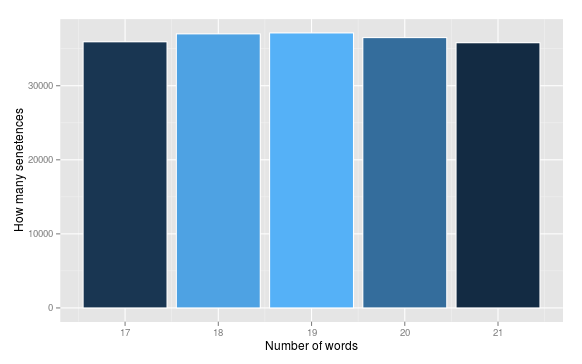